# What is the True Normal Human Body Temperature?

#### Background

The mean normal body temperature was held to be 37$^{\circ}$C or 98.6$^{\circ}$F for more than 120 years since it was first conceptualized and reported by Carl Wunderlich in a famous 1868 book. But, is this value statistically correct?

### Exercises

In this exercise, you will analyze a dataset of human body temperatures and employ the concepts of hypothesis testing, confidence intervals, and statistical significance.

Answer the following questions **in this notebook below and submit to your Github account**.

1. Is the distribution of body temperatures normal?
   - Although this is not a requirement for the Central Limit Theorem to hold (read the introduction on Wikipedia's page about the CLT carefully: https://en.wikipedia.org/wiki/Central_limit_theorem), it gives us some peace of mind that the population may also be normally distributed if we assume that this sample is representative of the population.
   - Think about the way you're going to check for the normality of the distribution. Graphical methods are usually used first, but there are also other ways: https://en.wikipedia.org/wiki/Normality_test
2. Is the sample size large? Are the observations independent?
   - Remember that this is a condition for the Central Limit Theorem, and hence the statistical tests we are using, to apply.
3. Is the true population mean really 98.6 degrees F?
   - First, try a bootstrap hypothesis test.
   - Now, let's try frequentist statistical testing. Would you use a one-sample or two-sample test? Why?
   - In this situation, is it appropriate to use the $t$ or $z$ statistic?
   - Now try using the other test. How is the result be different? Why?
4. Draw a small sample of size 10 from the data and repeat both frequentist tests.
   - Which one is the correct one to use?
   - What do you notice? What does this tell you about the difference in application of the $t$ and $z$ statistic?
5. At what temperature should we consider someone's temperature to be "abnormal"?
   - As in the previous example, try calculating everything using the boostrap approach, as well as the frequentist approach.
   - Start by computing the margin of error and confidence interval. When calculating the confidence interval, keep in mind that you should use the appropriate formula for one draw, and not N draws.
6. Is there a significant difference between males and females in normal temperature?
   - What testing approach did you use and why?
   - Write a story with your conclusion in the context of the original problem.

You can include written notes in notebook cells using Markdown:

- In the control panel at the top, choose Cell > Cell Type > Markdown
- Markdown syntax: http://nestacms.com/docs/creating-content/markdown-cheat-sheet

#### Resources

- Information and data sources: http://www.amstat.org/publications/jse/datasets/normtemp.txt, http://www.amstat.org/publications/jse/jse_data_archive.htm
- Markdown syntax: http://nestacms.com/docs/creating-content/markdown-cheat-sheet

```python
import pandas as pd
import matplotlib.pyplot as plt
import numpy as np
import scipy.stats as stats

df = pd.read_csv('data/human_body_temperature.csv')
```

```python
df.head()
```

|  | temperature | gender | heart_rate |
| --- | --- | --- | --- |
| 0 | 99.3 | F | 68.0 |
| 1 | 98.4 | F | 81.0 |
| 2 | 97.8 | M | 73.0 |
| 3 | 99.2 | F | 66.0 |
| 4 | 98.0 | F | 73.0 |

```python
df.info()
```

```
<class 'pandas.core.frame.DataFrame'>
RangeIndex: 130 entries, 0 to 129
Data columns (total 3 columns):
temperature    130 non-null float64
gender         130 non-null object
heart_rate     130 non-null float64
dtypes: float64(2), object(1)
memory usage: 3.1+ KB
```

```python
mean = np.mean(df.temperature)
mean
```

```
98.24923076923078
```

### Q1. Is the distribution of body temperatures normally distributed?

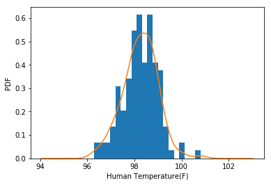

```python
plt.hist(df.temperature, bins = 20, density = True)
df.temperature.plot(kind = 'kde')
plt.xlabel('Human Temperature(F)')
plt.ylabel('PDF')
plt.show()
```

The distribution of body temperatures is approximately normally distributed, however, the peak is not perfectly symmetrical and there are some dips in the histogram.

Another non-graphical way to determine if the distribution of body temperatures is normally distributed is to use the scipy normaltest. This test assigns a probability that the distribution is normal.

Null hypothesis: The distribution of temperatures is normally distributed

```python
# SciPy normaltest
statistic, p_value = stats.normaltest(df.temperature)

print("p-value is ", p_value)
```

```
p-value is  0.2587479863488254
```

If using a 0.05 alpha threshhold, the p-value of 0.26 is not low enough to reject the null hypothesis. Therefore, there is insufficient evidence that the distribution of temperatures is not normally distributed.

### Q2. Is the sample size large? Are the observations independent?

```python
df.shape
```

```
(130, 3)
```

There are 130 obserations, which is large. The observations are independent because they are taken from separate people and presumably the temperature of one person is not influenced by the temperature of another.

### Q3. Is the true population mean really 98.6 degrees F?

##### First, try a bootstrap hypothesis test.

```python
sample_mean = np.mean(df['temperature'])
sample_std = np.std(df['temperature'])
conventional_mean = 98.6
```

Null Hypothesis: The true population mean is equal to the conventional mean of 98.6 degrees F.

T-Statistic: differene between sample mean and conventional mean.

Significance Threshhold: 0.05

```python
# Shift the mean of the sample data to 98.6 degrees to simulate data acquisition under the null hypothesis.
temp_shifted = df['temperature'] - sample_mean + conventional_mean
```

```python
#Calculating the test statistic
def diff_from_conventional(data, conventional_mean = 98.6):
    return np.mean(data) - conventional_mean
```

```python
# Observed test statistic
diff_obs = diff_from_conventional(df.temperature)
diff_obs
```

```
-0.35076923076921673
```

```python
def bootstrap_replicate_1d(data, func):
    """Draw one bootstrap replicate for a 1-d array of data"""
    return func(np.random.choice(data, size=len(data)))
```

```python
def draw_bs_reps(data, func, size=1):
    """Draw bootstrap replicates."""

    bs_replicates = np.empty(size)

    for i in range(size):
        bs_replicates[i] = bootstrap_replicate_1d(data, func)

    return bs_replicates
```

```python
bs_replicates_temp = draw_bs_reps(temp_shifted, diff_from_conventional, 10000)
```

```python
p_value = np.sum(bs_replicates_temp <= diff_obs) / 10000
print("p-value is :", p_value)
```

```
p-value is : 0.0
```

The p-value is zero, which would means the null hypothesis can be rejected.

##### Now, let's try frequentist statistical testing. Would you use a one-sample or two-sample test? Why?

For frequentist statistical testing, I would use a one-sample test because there is only one data set that that is being compared to a single value.

##### In this situation, is it appropriate to use the t or z statistic?

It is only appropriate to use a z-test if we know the population standard deviation and the sample size is greater than 30. While the sample is over 30, we do not know the true population standard deviation, so the t-test would be more appropriate. If we use the sample standard deviation as representative of the true population standard deviation, we can use the z-test.

```python
# one sample t-test
t_stat, p_value = stats.ttest_1samp(df.temperature, conventional_mean)

print("p-value: ", p_value)
```

```
p-value:  2.4106320415561276e-07
```

The p-value is well below 0.05, and the null hypothesis can be rejected.

##### Now try using the other test. How is the result be different? Why?

```python
# one sample z-test
z = (sample_mean - conventional_mean)/(sample_std/np.sqrt(len(df.temperature)))
p_value = stats.norm.sf(abs(z))
print('p-value = ', p_value)
```

```
p-value =  2.1761575829410943e-08
```

The p-value is smaller than 0.05, and smaller than with the t-test, indicating that the null hypothesis can be rejected.

### Q4. Draw a small sample of size 10 from the data and repeat both frequentist tests.

```python
sample_10 = np.random.choice(df.temperature, size=10)
```

```python
mean = np.mean(sample_10)
std = np.std(sample_10)
```

```python
# one-sample t-test
t_stat, p_value = stats.ttest_1samp(sample_10, conventional_mean)
print('p-value = ', p_value)
```

```
p-value =  0.04841433415702171
```

```python
# one sample z-test
z = (mean - conventional_mean)/(std/np.sqrt(len(sample_10)))
p_value = stats.norm.sf(abs(z))
print('p_value = ', p_value)
```

```
p_value =  0.00807958947117413
```

##### Which one is the correct one to use?

##### What do you notice? What does this tell you about the difference in application of the t and z statistic?

The null hypothesis can be rejected with the t-test and the z-test with this sample of 10, however, the p-values are not nearly as low since with a smaller sample there is greater uncertainty. The correct test to use with a small sample size of 10 is the t-test, since it is more conservative and indeed, the p-value with the t-test is only slightly below the significance threshhold.

### Q5. At what temperature should we consider someone's temperature to be "abnormal"?

##### As in the previous example, try calculating everything using the boostrap approach, as well as the frequentist approach.

##### Start by computing the margin of error and confidence interval. When calculating the confidence interval, keep in mind that you should use the appropriate formula for one draw, and not N draws.

If "abnormal" temperature is defined as temperatures outside the 95% confidence interval, bootstrapping can be used to find the "normal" temperatures within the 95% confidence interval

```python
bs_replicates = [np.random.choice(df.temperature, size = 10000)]
bs_ci = np.percentile(bs_replicates, [2.5, 97.5])
print('Bootstrap confidence interval:', bs_ci)
```

```
Bootstrap confidence interval: [96.7 99.5]
```

The boundaries of the 95% confidence interval are 96.7 and 99.5 degrees, meaning temperatures above 99.5 or below 96.7 would be considered "abnormal".

We can also use the a frequenstist approch to determine "abnormal" temperatures considering the same 95% confidence interval as "normal".

```python
z_critical_value = stats.norm.ppf(0.975)
z_critical_value
```

```
1.959963984540054
```

```python
margin_of_error = (sample_std/np.sqrt(len(df)) * z_critical_value)
margin_of_error
```

```
0.12554865777413815
```

```python
# z test
conf_int = stats.norm.interval(0.95, loc=sample_mean, scale = sample_std)
print(conf_int)
```

```
(96.81775582674824, 99.68070571171332)
```

From the z-test, temperatures below 96.82 or above 99.68 would be considered abnormal.

### Q6. Is there a significant difference between males and females in normal temperature?

##### What testing approach did you use and why?

To test if there is a significant difference between males and females in normal temperature, the data will be split into two groups, Male and Female, and a two-sample test can be performed since there we want to see if there is a significant difference between the two populations.

The null hypothesis is that there is not a significant difference in mean temperature between males and females.

Significance Level: 0.05

```python
df_male = df[df['gender'] == 'M']
df_female = df[df['gender'] == 'F']
print("Mean temperature for males is ",np.mean(df_male.temperature))
print("Mean temperature for females is ",np.mean(df_female.temperature))
```

```
Mean temperature for males is  98.1046153846154
Mean temperature for females is  98.39384615384613
```

```python
t_stat, p_value = stats.ttest_ind(df_male.temperature, df_female.temperature)

p_value
```

```
0.02393188312239561
```

The p-value of .0239 is less than 0.05, meaning that the oberved difference between males and females would only have a 2.39% chance of occuring if the null hypothesis were true. Since it is below the significance level of 0.05, we can reject the null hypotheses and conclude there is a significant difference in temperature between males and females.

##### Write a story with your conclusion in the context of the original problem.

The conventional normal human body temperature has been considered to be 98.6 degrees since an 1868 book by Carl Wunderlich . Statistical analysis reveals that this is likely incorrect. The mean body temperature of the data analyzed is 98.25 degrees. The probability of obtaining a sample with a mean of 98.25 was determined to be near zero if the true mean was 98.6 degrees, showing strong evidence that 98.6 is not the true mean body temperature.

Additionally, the data sample collected shows a difference in mean temperature between males and females of about 0.3 degrees. Statistical analysis shows that this is a significant difference that is unlikey to occur in a sample if males and females have the same mean temperature, indicating it is unlikely that males and females have the same mean temperature.